# Dummies

Wayne Stewart

March 2, 2018

# Categorical Variables

In many applications we will need to incorporate categorical variables into our regression. How is this to be done?

```r
data(mtcars)
head(mtcars)
```

```
##                    mpg cyl disp  hp drat    wt  qsec vs am gear carb
## Mazda RX4         21.0   6  160 110 3.90 2.620 16.46  0  1    4    4
## Mazda RX4 Wag     21.0   6  160 110 3.90 2.875 17.02  0  1    4    4
## Datsun 710        22.8   4  108  93 3.85 2.320 18.61  1  1    4    1
## Hornet 4 Drive    21.4   6  258 110 3.08 3.215 19.44  1  0    3    1
## Hornet Sportabout 18.7   8  360 175 3.15 3.440 17.02  0  0    3    2
## Valiant           18.1   6  225 105 2.76 3.460 20.22  1  0    3    1
```

```r
dim(mtcars)[1]
```

```
## [1] 32
```

We will define some variables to be factors

```r
mycars = within(mtcars, {
  cylF<-factor(cyl)
  vsF <- factor(vs)
  amF <- factor(am)
  gearF <- factor(gear)
  carbF <- factor(carb)
})

head(mycars)
```

```
##                    mpg cyl disp  hp drat    wt  qsec vs am gear carb carbF
## Mazda RX4         21.0   6  160 110 3.90 2.620 16.46  0  1    4    4     4
## Mazda RX4 Wag     21.0   6  160 110 3.90 2.875 17.02  0  1    4    4     4
## Datsun 710        22.8   4  108  93 3.85 2.320 18.61  1  1    4    1     1
## Hornet 4 Drive    21.4   6  258 110 3.08 3.215 19.44  1  0    3    1     1
## Hornet Sportabout 18.7   8  360 175 3.15 3.440 17.02  0  0    3    2     2
## Valiant           18.1   6  225 105 2.76 3.460 20.22  1  0    3    1     1
##                   gearF amF vsF cylF
## Mazda RX4             4   1   0    6
## Mazda RX4 Wag         4   1   0    6
## Datsun 710            4   1   1    4
## Hornet 4 Drive        3   0   1    6
## Hornet Sportabout     3   0   0    8
## Valiant               3   0   1    6
```

```r
table(mycars$carbF)
```

```
##
##  1  2  3  4  6  8
##  7 10  3 10  1  1
```

# Using classical methods

```r
mpglm = lm(mpg~disp + carbF, data =mycars )
summary(mpglm)
```

```
##
## Call:
## lm(formula = mpg ~ disp + carbF, data = mycars)
##
## Residuals:
##     Min      1Q  Median      3Q     Max
## -4.3359 -1.6135  0.0321  1.1194  6.3592
##
## Coefficients:
##              Estimate Std. Error t value Pr(>|t|)
## (Intercept) 30.014542   1.350232  22.229  < 2e-16 ***
## disp        -0.034793   0.005309  -6.554 7.26e-07 ***
## carbF2      -0.372064   1.545757  -0.241   0.8118
## carbF3      -4.118676   2.224379  -1.852   0.0759 .
## carbF4      -3.479816   1.759031  -1.978   0.0590 .
## carbF6      -5.269580   3.243950  -1.624   0.1168
## carbF8      -4.541896   3.362060  -1.351   0.1888
## ---
## Signif. codes:  0 '***' 0.001 '**' 0.01 '*' 0.05 '.' 0.1 ' ' 1
##
## Residual standard error: 3.034 on 25 degrees of freedom
## Multiple R-squared:  0.7956, Adjusted R-squared:  0.7466
## F-statistic: 16.22 on 6 and 25 DF,  p-value: 1.544e-07
```

# Look at the Dummy Variables

We can extract the design matrix by using the following:

```r
mm=model.matrix(mpglm)
df = as.data.frame(mm)

lst = as.list(df)
df
```

```
##                     (Intercept)  disp carbF2 carbF3 carbF4 carbF6 carbF8
## Mazda RX4                     1 160.0      0      0      1      0      0
## Mazda RX4 Wag                 1 160.0      0      0      1      0      0
## Datsun 710                    1 108.0      0      0      0      0      0
## Hornet 4 Drive                1 258.0      0      0      0      0      0
## Hornet Sportabout             1 360.0      1      0      0      0      0
## Valiant                       1 225.0      0      0      0      0      0
## Duster 360                    1 360.0      0      0      1      0      0
## Merc 240D                     1 146.7      1      0      0      0      0
## Merc 230                      1 140.8      1      0      0      0      0
## Merc 280                      1 167.6      0      0      1      0      0
## Merc 280C                     1 167.6      0      0      1      0      0
## Merc 450SE                    1 275.8      0      1      0      0      0
## Merc 450SL                    1 275.8      0      1      0      0      0
## Merc 450SLC                   1 275.8      0      1      0      0      0
## Cadillac Fleetwood            1 472.0      0      0      1      0      0
## Lincoln Continental           1 460.0      0      0      1      0      0
## Chrysler Imperial             1 440.0      0      0      1      0      0
## Fiat 128                      1  78.7      0      0      0      0      0
## Honda Civic                   1  75.7      1      0      0      0      0
## Toyota Corolla                1  71.1      0      0      0      0      0
## Toyota Corona                 1 120.1      0      0      0      0      0
## Dodge Challenger              1 318.0      1      0      0      0      0
## AMC Javelin                   1 304.0      1      0      0      0      0
## Camaro Z28                    1 350.0      0      0      1      0      0
## Pontiac Firebird              1 400.0      1      0      0      0      0
## Fiat X1-9                     1  79.0      0      0      0      0      0
## Porsche 914-2                 1 120.3      1      0      0      0      0
## Lotus Europa                  1  95.1      1      0      0      0      0
## Ford Pantera L                1 351.0      0      0      1      0      0
## Ferrari Dino                  1 145.0      0      0      0      1      0
## Maserati Bora                 1 301.0      0      0      0      0      1
## Volvo 142E                    1 121.0      1      0      0      0      0
```

Also the data used in the model

```r
df2=model.frame(mpglm)
head(df2)
```

```
##                    mpg disp carbF
## Mazda RX4         21.0  160     4
## Mazda RX4 Wag     21.0  160     4
## Datsun 710        22.8  108     1
## Hornet 4 Drive    21.4  258     1
## Hornet Sportabout 18.7  360     2
## Valiant           18.1  225     1
```

```r
dput(df2)
```

```
## structure(list(mpg = c(21, 21, 22.8, 21.4, 18.7, 18.1, 14.3,
## 24.4, 22.8, 19.2, 17.8, 16.4, 17.3, 15.2, 10.4, 10.4, 14.7, 32.4,
## 30.4, 33.9, 21.5, 15.5, 15.2, 13.3, 19.2, 27.3, 26, 30.4, 15.8,
## 19.7, 15, 21.4), disp = c(160, 160, 108, 258, 360, 225, 360,
## 146.7, 140.8, 167.6, 167.6, 275.8, 275.8, 275.8, 472, 460, 440,
## 78.7, 75.7, 71.1, 120.1, 318, 304, 350, 400, 79, 120.3, 95.1,
## 351, 145, 301, 121), carbF = structure(c(4L, 4L, 1L, 1L, 2L,
## 1L, 4L, 2L, 2L, 4L, 4L, 3L, 3L, 3L, 4L, 4L, 4L, 1L, 2L, 1L, 1L,
## 2L, 2L, 4L, 2L, 1L, 2L, 2L, 4L, 5L, 6L, 2L), .Label = c("1",
## "2", "3", "4", "6", "8"), class = "factor")), terms = mpg ~ disp +
##     carbF, row.names = c("Mazda RX4", "Mazda RX4 Wag", "Datsun 710",
## "Hornet 4 Drive", "Hornet Sportabout", "Valiant", "Duster 360",
## "Merc 240D", "Merc 230", "Merc 280", "Merc 280C", "Merc 450SE",
## "Merc 450SL", "Merc 450SLC", "Cadillac Fleetwood", "Lincoln Continental",
## "Chrysler Imperial", "Fiat 128", "Honda Civic", "Toyota Corolla",
## "Toyota Corona", "Dodge Challenger", "AMC Javelin", "Camaro Z28",
## "Pontiac Firebird", "Fiat X1-9", "Porsche 914-2", "Lotus Europa",
## "Ford Pantera L", "Ferrari Dino", "Maserati Bora", "Volvo 142E"
## ), class = "data.frame")
```

# The expression of the model

$$y = \beta_0 + \beta_1 x + \beta_2 carbF2 + \beta_3 carbF3 + \beta_4 carbF4 + \beta_5 carbF6 + \beta_6 carbF8 + \epsilon$$

# How to interpret dummy variables

## We will use the same data set and plot parallel lines

Below is the code used to make a visual of the model estimation

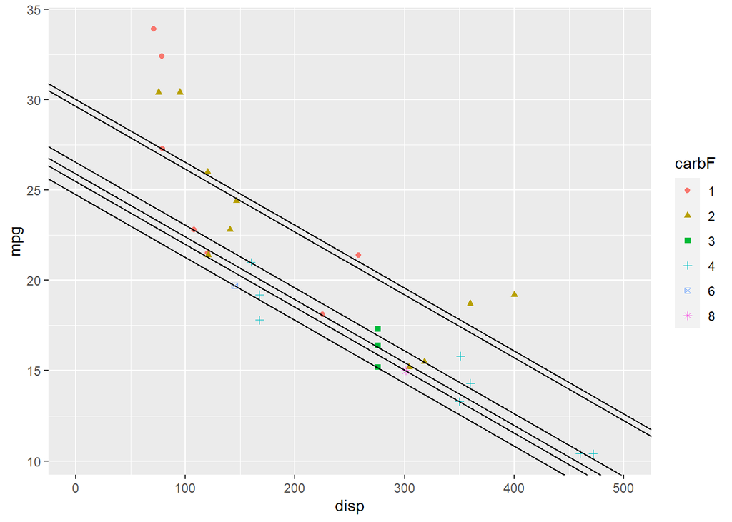

```r
library(ggplot2)
pred = predict(mpglm)

cf=coef(mpglm) # obtain the coefficients

int = cf[1]+c(0,cf[-c(1,2)]) # intercepts (6)

gg = ggplot(mycars, aes(x = disp, y =mpg, group = carbF, color = carbF, shape = carbF)) + geom_point()  +
  geom_abline(intercept =int, slope = cf[2], aes(colour = carbF)) + xlim(0,500)
gg
```

```r
cf
```

```
## (Intercept)        disp      carbF2      carbF3      carbF4      carbF6
## 30.01454180 -0.03479284 -0.37206372 -4.11867586 -3.47981620 -5.26957965
##      carbF8
## -4.54189623
```

## Interpretation

All carburetor groups are relative to the reference group (1 carb.). The intercept for each line is calculated by adding the coefficient of each Dummy variable to the base or reference level intercept. If the coefficient is negative it will indicate a group below the reference. If it is positive then above the reference group.

# Use a Bayesian approach

## Make up the model file either by adjusting slr or starting from scratch.

Data as a list

```r
dput(df[,-1])
```

```
## structure(list(disp = c(160, 160, 108, 258, 360, 225, 360, 146.7,
## 140.8, 167.6, 167.6, 275.8, 275.8, 275.8, 472, 460, 440, 78.7,
## 75.7, 71.1, 120.1, 318, 304, 350, 400, 79, 120.3, 95.1, 351,
## 145, 301, 121), carbF2 = c(0, 0, 0, 0, 1, 0, 0, 1, 1, 0, 0, 0,
## 0, 0, 0, 0, 0, 0, 1, 0, 0, 1, 1, 0, 1, 0, 1, 1, 0, 0, 0, 1),
##     carbF3 = c(0, 0, 0, 0, 0, 0, 0, 0, 0, 0, 0, 1, 1, 1, 0, 0,
##     0, 0, 0, 0, 0, 0, 0, 0, 0, 0, 0, 0, 0, 0, 0, 0), carbF4 = c(1,
##     1, 0, 0, 0, 0, 1, 0, 0, 1, 1, 0, 0, 0, 1, 1, 1, 0, 0, 0,
##     0, 0, 0, 1, 0, 0, 0, 0, 1, 0, 0, 0), carbF6 = c(0, 0, 0,
##     0, 0, 0, 0, 0, 0, 0, 0, 0, 0, 0, 0, 0, 0, 0, 0, 0, 0, 0,
##     0, 0, 0, 0, 0, 0, 0, 1, 0, 0), carbF8 = c(0, 0, 0, 0, 0,
##     0, 0, 0, 0, 0, 0, 0, 0, 0, 0, 0, 0, 0, 0, 0, 0, 0, 0, 0,
##     0, 0, 0, 0, 0, 0, 1, 0)), class = "data.frame", row.names = c("Mazda RX4",
## "Mazda RX4 Wag", "Datsun 710", "Hornet 4 Drive", "Hornet Sportabout",
## "Valiant", "Duster 360", "Merc 240D", "Merc 230", "Merc 280",
## "Merc 280C", "Merc 450SE", "Merc 450SL", "Merc 450SLC", "Cadillac Fleetwood",
## "Lincoln Continental", "Chrysler Imperial", "Fiat 128", "Honda Civic",
## "Toyota Corolla", "Toyota Corona", "Dodge Challenger", "AMC Javelin",
## "Camaro Z28", "Pontiac Firebird", "Fiat X1-9", "Porsche 914-2",
## "Lotus Europa", "Ford Pantera L", "Ferrari Dino", "Maserati Bora",
## "Volvo 142E"))
```

```r
require(rjags)               # Must have previously installed package rjags.


Ntotal = dim(mtcars)[1]
fileNameRoot="categotical" # For output file names.
dataList=list(mpg = c(21, 21, 22.8, 21.4, 18.7, 18.1, 14.3,
24.4, 22.8, 19.2, 17.8, 16.4, 17.3, 15.2, 10.4, 10.4, 14.7, 32.4,
30.4, 33.9, 21.5, 15.5, 15.2, 13.3, 19.2, 27.3, 26, 30.4, 15.8,
19.7, 15, 21.4),disp = c(160, 160, 108, 258, 360, 225, 360, 146.7,
140.8, 167.6, 167.6, 275.8, 275.8, 275.8, 472, 460, 440, 78.7,
75.7, 71.1, 120.1, 318, 304, 350, 400, 79, 120.3, 95.1, 351,
145, 301, 121), carbF2 = c(0, 0, 0, 0, 1, 0, 0, 1, 1, 0, 0, 0,
0, 0, 0, 0, 0, 0, 1, 0, 0, 1, 1, 0, 1, 0, 1, 1, 0, 0, 0, 1),
    carbF3 = c(0, 0, 0, 0, 0, 0, 0, 0, 0, 0, 0, 1, 1, 1, 0, 0,
    0, 0, 0, 0, 0, 0, 0, 0, 0, 0, 0, 0, 0, 0, 0, 0), carbF4 = c(1,
    1, 0, 0, 0, 0, 1, 0, 0, 1, 1, 0, 0, 0, 1, 1, 1, 0, 0, 0,
    0, 0, 0, 1, 0, 0, 0, 0, 1, 0, 0, 0), carbF6 = c(0, 0, 0,
    0, 0, 0, 0, 0, 0, 0, 0, 0, 0, 0, 0, 0, 0, 0, 0, 0, 0, 0,
    0, 0, 0, 0, 0, 0, 0, 1, 0, 0), carbF8 = c(0, 0, 0, 0, 0,
    0, 0, 0, 0, 0, 0, 0, 0, 0, 0, 0, 0, 0, 0, 0, 0, 0, 0, 0,
    0, 0, 0, 0, 0, 0, 1, 0), Ntotal = Ntotal)


#Define the model:
modelString = "
model{
for(i in 1:Ntotal)
{


}
" # close quote for modelString
writeLines( modelString , con="TEMPmodel.txt" )

# Initialize the chains based on MLE of data.
# Option: Use single initial value for all chains:
#  thetaInit = sum(y)/length(y)
#  initsList = list( theta=thetaInit )

initsList = list(beta0 = 0, beta1 = 0, beta2=0, beta3=0, beta4=0, betaq5=0, beta6=0, sigma =10)

# Run the chains:
jagsModel = jags.model( file="TEMPmodel.txt" , data=dataList , inits=initsList ,
                        n.chains=3 , n.adapt=500 )
update( jagsModel , n.iter=500 )
codaSamples = coda.samples( jagsModel , variable.names=c("beta0", "beta1", "beta2" ,"sigma") ,
                            n.iter=33340 )
save( codaSamples , file=paste0(fileNameRoot,"Mcmc.Rdata") )

summary(codaSamples)
```

[output not shown]

# Part B of Categorical Data

## Some artificial data

Suppose `y` is the length of plants and `x` is the age.

```r
x1 = 1:40
set.seed(33)
y1=10+8*x1 + rnorm(40,0,12)
set.seed(44)
y2 = 125+8*x1 + rnorm(40,0,12)
y = c(y1,y2)
x = c(x1,x1)
plant = rep(c("A","B"), c(40,40))

y.lm = lm(y ~ x + plant)
summary(y.lm)
```

```
##
## Call:
## lm(formula = y ~ x + plant)
##
## Residuals:
##     Min      1Q  Median      3Q     Max
## -27.462  -6.933  -0.225   6.203  37.054
##
## Coefficients:
##             Estimate Std. Error t value Pr(>|t|)
## (Intercept)   8.4910     2.9586    2.87   0.0053 **
## x             8.1473     0.1129   72.16   <2e-16 ***
## plantB      113.0427     2.6065   43.37   <2e-16 ***
## ---
## Signif. codes:  0 '***' 0.001 '**' 0.01 '*' 0.05 '.' 0.1 ' ' 1
##
## Residual standard error: 11.66 on 77 degrees of freedom
## Multiple R-squared:  0.9893, Adjusted R-squared:  0.989
## F-statistic:  3544 on 2 and 77 DF,  p-value: < 2.2e-16
```

```r
head(model.matrix(y.lm))
```

```
##   (Intercept) x plantB
## 1           1 1      0
## 2           1 2      0
## 3           1 3      0
## 4           1 4      0
## 5           1 5      0
## 6           1 6      0
```

```r
cf=coef(y.lm)
```

Lets plot the graphs

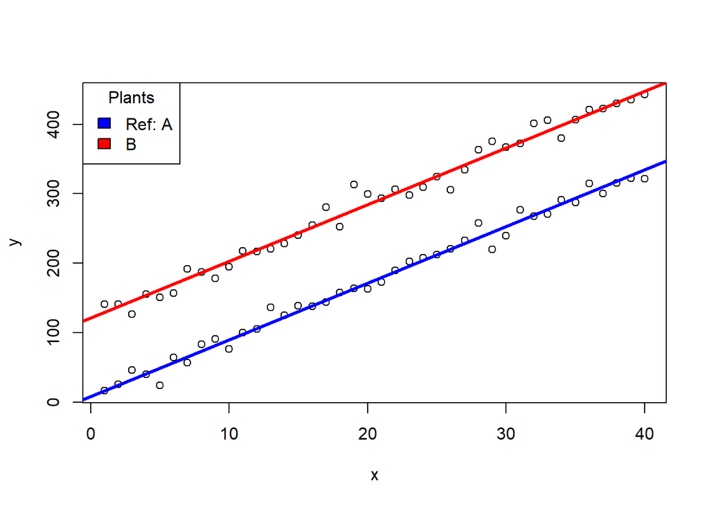

```r
plot(y~x)
abline(coef=cf[1:2], lwd =3, col = "Blue")
abline(coef =c(cf[1] +cf[3],cf[2]),lwd =3, col = "Red")
legend("topleft",legend = c("Ref: A","B"),fill =c("Blue","Red"), title = "Plants")
```

## Interpretation

Plants A and B grow at the same rate (slope) but plant A the reference is always smaller for a given age `x`

# Interaction

## The data

```r
x1 = 1:40
set.seed(33)
y1=10+8*x1 + rnorm(40,0,12) #A
set.seed(44)
y2 = 125+20*x1 + rnorm(40,0,12) # B
y = c(y1,y2)
x = c(x1,x1)
plant = rep(c("A","B"), c(40,40))
```

```r
yy.lm = lm(y ~ x + plant + x:plant)
summary(yy.lm)
```

```
##
## Call:
## lm(formula = y ~ x + plant + x:plant)
##
## Residuals:
##     Min      1Q  Median      3Q     Max
## -28.002  -6.763  -0.895   5.729  37.201
##
## Coefficients:
##             Estimate Std. Error t value Pr(>|t|)
## (Intercept)  10.5019     3.7624   2.791  0.00664 **
## x             8.0492     0.1599  50.333  < 2e-16 ***
## plantB      109.0209     5.3208  20.489  < 2e-16 ***
## x:plantB     12.1962     0.2262  53.927  < 2e-16 ***
## ---
## Signif. codes:  0 '***' 0.001 '**' 0.01 '*' 0.05 '.' 0.1 ' ' 1
##
## Residual standard error: 11.68 on 76 degrees of freedom
## Multiple R-squared:  0.998,  Adjusted R-squared:  0.9979
## F-statistic: 1.249e+04 on 3 and 76 DF,  p-value: < 2.2e-16
```

```r
plot(y~x)
cf2 = coef(yy.lm)
cf2
```

```
## (Intercept)           x      plantB    x:plantB
##   10.501910    8.049226  109.020944   12.196182
```

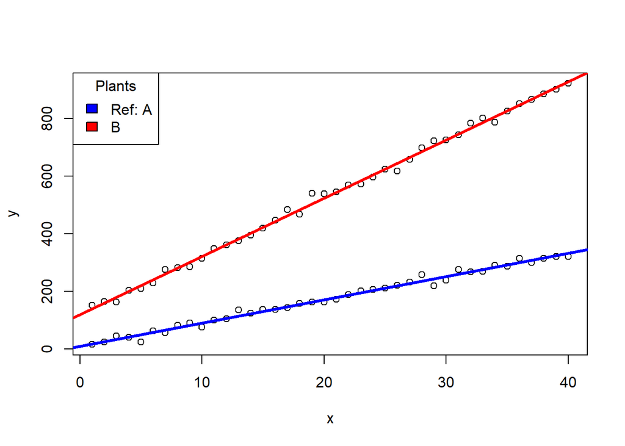

```r
abline(coef = c(cf2[1],cf2[2]), col="Blue", lwd =3)
abline(coef = c(cf2[1]+cf2[3], cf2[2]+cf2[4]), col = "Red", lwd = 3)
legend("topleft",legend = c("Ref: A","B"),fill =c("Blue","Red"), title = "Plants")
```

Notice: 1) that for the difference in length depends on the age – this means that the age and type of plant interact 2) that the interaction term is easily interpreted – put the dummy variable for plantb equal 0 (this is equivalent to the slope of A)

```r
model.matrix(yy.lm)
```

```
##    (Intercept)  x plantB x:plantB
## 1            1  1      0        0
## 2            1  2      0        0
## 3            1  3      0        0
## 4            1  4      0        0
## 5            1  5      0        0
## 6            1  6      0        0
## 7            1  7      0        0
## 8            1  8      0        0
## 9            1  9      0        0
## 10           1 10      0        0
## 11           1 11      0        0
## 12           1 12      0        0
## 13           1 13      0        0
## 14           1 14      0        0
```

[output cut: 71 more lines]

# The model

$$y=\beta_0 + \beta_1 x + \beta_2 plantB + \beta_3 x plantB +\epsilon$$

Note that `plantB` is a dummy variable (Takes 0,1) and

$$\epsilon\sim N(0,\sigma^2)$$

That is to say using subscripts

$$y_i \stackrel{iid}{\sim} N(\mu_i, \sigma^2)$$

Where $\mu_i$ is defined below as a linear predictor $\eta_i$

$$\mu_i=\eta_i = \beta_0 + \beta_1 x_i + \beta_2 plantB_i + \beta_3 x_i plantB_i$$

## Interpretation

If $plantB_i = 0$ then

$$\mu_i = \beta_0 + \beta_1 x_i$$

This will be the part of the model explaining the Blue line.

If $plantB_i = 1$ then

$$\beta_0 + \beta_1 x_i + \beta_2 *1 + \beta_3 x_i *1$$
So collecting terms:

$$\mu_i = (\beta_0+ \beta_2) + (\beta_1+\beta_3)x_i$$
This will expalin the red line.

# Make a Bayesian model

## Use OpenBUGS and make a model for the interaction above. Put everything into this RMD document

1. Place a picture here `![](){}`
2. Create a JAGS script run the model with priors that you justify (USE THE SAME DATA AS ABOVE)
3. Diagnose the MCMC with JK’s plots
4. Estimate the parameters – give point and interval estimates. These must be interpreted.
5. Use ggmcmc and improve the plots (see documentation for the package)